# Lab 8: Neural Networks

Lizzy Presland

March 13, 2019

## Exploring and Preparing Data

```r
data_raw <- read.csv("concrete.csv", stringsAsFactors = TRUE)
# Q1
summary(data_raw)
```

```
##      cement           slag            ash             water
##  Min.   :102.0   Min.   :  0.0   Min.   :  0.00   Min.   :121.8
##  1st Qu.:192.4   1st Qu.:  0.0   1st Qu.:  0.00   1st Qu.:164.9
##  Median :272.9   Median : 22.0   Median :  0.00   Median :185.0
##  Mean   :281.2   Mean   : 73.9   Mean   : 54.19   Mean   :181.6
##  3rd Qu.:350.0   3rd Qu.:142.9   3rd Qu.:118.30   3rd Qu.:192.0
##  Max.   :540.0   Max.   :359.4   Max.   :200.10   Max.   :247.0
##   superplastic      coarseagg         fineagg           age
##  Min.   : 0.000   Min.   : 801.0   Min.   :594.0   Min.   :  1.00
##  1st Qu.: 0.000   1st Qu.: 932.0   1st Qu.:731.0   1st Qu.:  7.00
##  Median : 6.400   Median : 968.0   Median :779.5   Median : 28.00
##  Mean   : 6.205   Mean   : 972.9   Mean   :773.6   Mean   : 45.66
##  3rd Qu.:10.200   3rd Qu.:1029.4   3rd Qu.:824.0   3rd Qu.: 56.00
##  Max.   :32.200   Max.   :1145.0   Max.   :992.6   Max.   :365.00
##     strength
##  Min.   : 2.33
##  1st Qu.:23.71
##  Median :34.45
##  Mean   :35.82
##  3rd Qu.:46.13
##  Max.   :82.60
```

#### Question 2:

There are eight features that are informative for the target variable, which I believe is `strength`. The ingredients are provided in units of kilograms per cubic meter, which may require some processing.

#### Question 3:

```r
data_raw <- as.data.frame(lapply(data_raw, scale))
summary(data_raw)
```

```
##      cement              slag              ash              water
##  Min.   :-1.71442   Min.   :-0.8565   Min.   :-0.8467   Min.   :-2.7989
##  1st Qu.:-0.84964   1st Qu.:-0.8565   1st Qu.:-0.8467   1st Qu.:-0.7805
##  Median :-0.07911   Median :-0.6015   Median :-0.8467   Median : 0.1608
##  Mean   : 0.00000   Mean   : 0.0000   Mean   : 0.0000   Mean   : 0.0000
##  3rd Qu.: 0.65864   3rd Qu.: 0.8004   3rd Qu.: 1.0018   3rd Qu.: 0.4886
##  Max.   : 2.47671   Max.   : 3.3091   Max.   : 2.2800   Max.   : 3.0642
##   superplastic       coarseagg           fineagg              age
##  Min.   :-1.0386   Min.   :-2.21106   Min.   :-2.23983   Min.   :-0.7070
##  1st Qu.:-1.0386   1st Qu.:-0.52626   1st Qu.:-0.53171   1st Qu.:-0.6120
##  Median : 0.0327   Median :-0.06326   Median : 0.07383   Median :-0.2796
##  Mean   : 0.0000   Mean   : 0.00000   Mean   : 0.00000   Mean   : 0.0000
##  3rd Qu.: 0.6688   3rd Qu.: 0.72641   3rd Qu.: 0.62886   3rd Qu.: 0.1637
##  Max.   : 4.3515   Max.   : 2.21315   Max.   : 2.73173   Max.   : 5.0552
##     strength
##  Min.   :-2.00458
##  1st Qu.:-0.72478
##  Median :-0.08218
##  Mean   : 0.00000
##  3rd Qu.: 0.61757
##  Max.   : 2.80036
```

#### Question 4:

```r
# let's set a seed for the sample() function
set.seed(123)
partition_vector <- sample(nrow(data_raw), 0.75 * nrow(data_raw))
data_train <- data_raw[partition_vector,]
data_test <- data_raw[-partition_vector,]
```

## Training a Model on the Data

#### Question 5:

```r
library(neuralnet)
```

#### Question 6:

```r
# let's set another seed for the model
# set.seed(321)
concrete_model <- neuralnet(strength ~ cement + slag + ash, data=data_train)
```

#### Question 7:

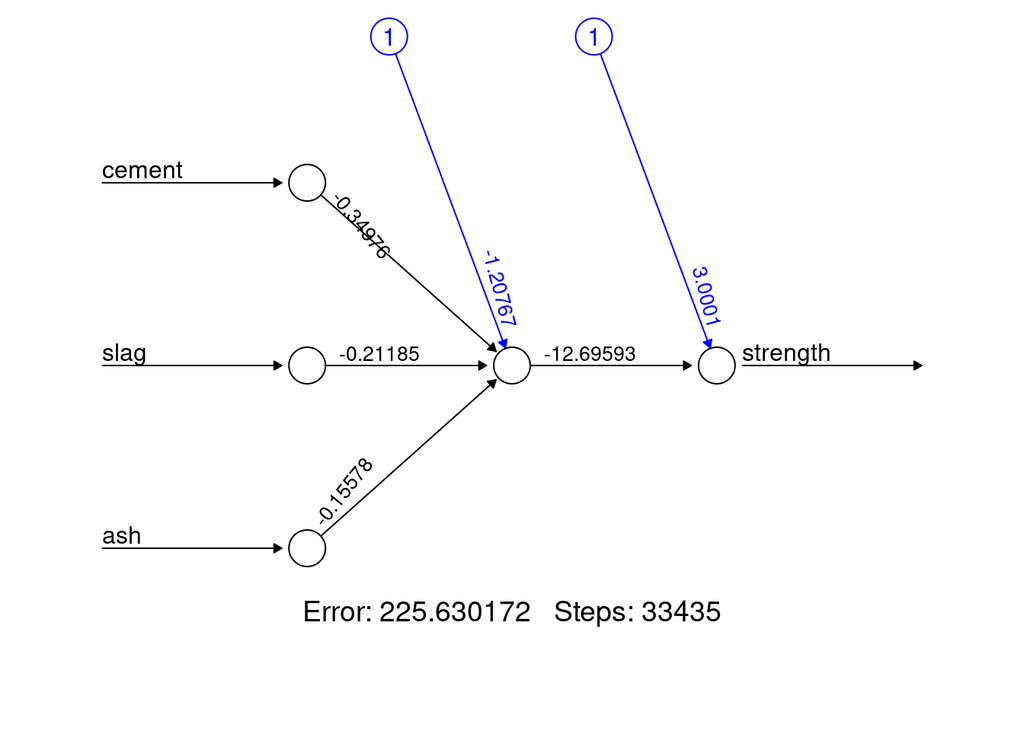

```r
plot(concrete_model, rep="best")
```

## Evaluating Model Performance

#### Question 8:

```r
model_results <- compute(concrete_model, data_test)
# the line below will display the prediction vector based off of normalized values
# model_results$net.result
```

#### Question 9:

We can obtain the `$neurons` object, which stores the neurons for each layer in the network, and `$net.result`, which stores the model’s predicted values.

The `$neurons` object might be difficult to understand for us, because it contains a representation of each neuron. However, the `$net.result` vector gives us a vector of predicted strength values for the test dataset, which we can compare directly with the actual vector of values from the `data_test` dataframe.

#### Question 10:

```r
correlation <- cor(model_results$net.result, data_test$strength)
```

There is a correlation of 0.6123159, which is reasonable, but we can definitely do better. The typical correlation value I have been getting is 60-70% (before setting a fixed seed value).

## Improving Model Performance

#### Question 11:

```r
concrete_model <- neuralnet(strength ~ cement + slag + ash, data=data_train, hidden = 5)
```

#### Question 12:

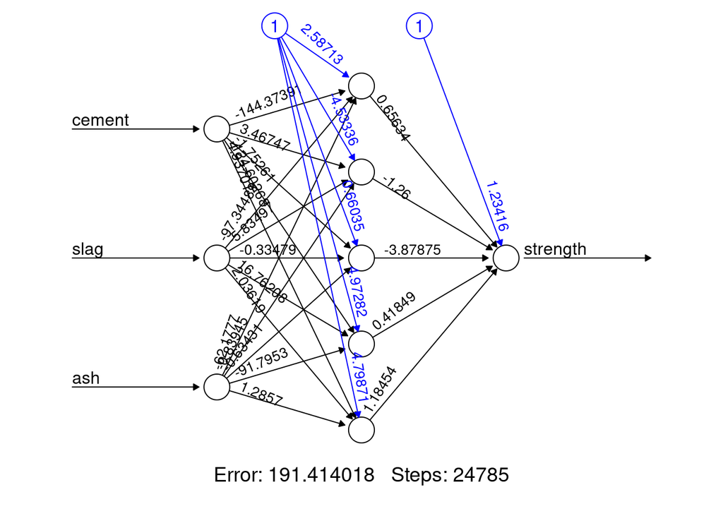

```r
plot(concrete_model, rep="best")
```

Our new plot for more hidden layers produces a lower error rate (from ~225 to ~191) with fewer steps.

#### Question 13:

```r
model_results <- compute(concrete_model, data_test)
```

#### Question 14:

```r
correlation_new <- cor(model_results$net.result, data_test$strength)
```

Our original correlation value was 0.6123159 and our new correlation value is 0.6510941; this is an improvement of approximately 3.9%.

## Extra Things

The example method call for `neuralnet()` listed only three factors - this section will examine the results for using all 8 features in the dataset.

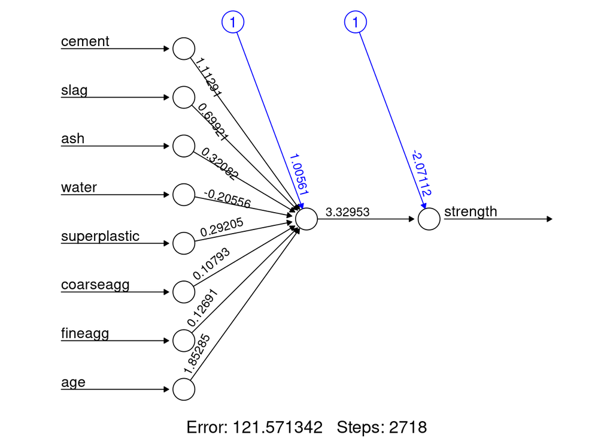

```r
concrete_model <- neuralnet(strength ~ cement + slag + ash + water + superplastic + coarseagg + fineagg + age, data=data_train)

plot(concrete_model, rep="best")
```

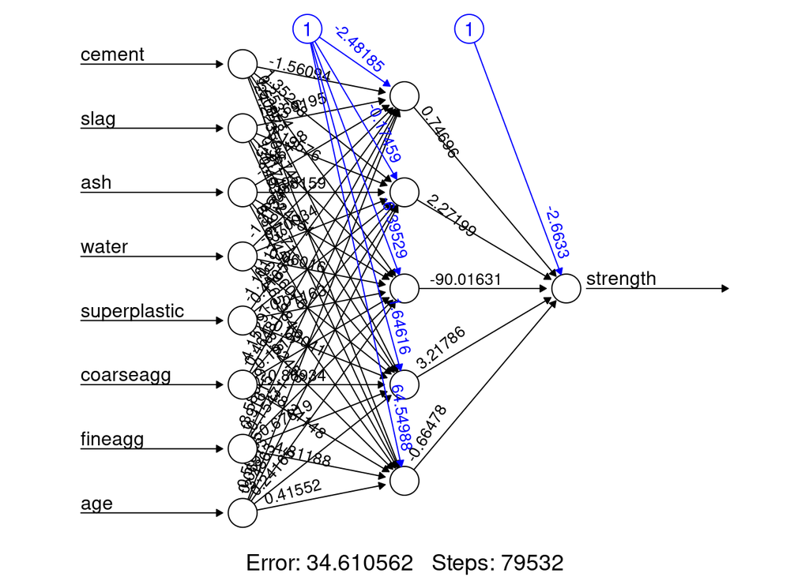

```r
model_results <- compute(concrete_model, data_test)
correlation_8 <- cor(model_results$net.result, data_test$strength)
concrete_model <- neuralnet(strength ~ cement + slag + ash + water + superplastic + coarseagg + fineagg + age, data=data_train, hidden = 5)
plot(concrete_model, rep="best")
```

```r
model_results <- compute(concrete_model, data_test)
correlation_8_new <- cor(model_results$net.result, data_test$strength)
```

Compared to our original results:

| Model Type | Correlation | Improvement Over First Iteration |
| --- | --- | --- |
| 1 hidden node, 3 features | 0.6123159 | N/A |
| 5 hidden nodes, 3 features | 0.6510941 | 3.9% |
| 1 hidden node, 8 features | 0.8374147 | 22.5% |
| 5 hidden nodes, 8 features | 0.9333507 | 32.1% |

It’s not very surprising that utilizing all features will improve our results substantially; it is very cool to see that using more hidden nodes provides substanital gains (almost 10% of correlation value) when all features are used.